# ANCOVA in flow (prod. textual) (flow (prod. textual))

Geiser C. Challco geiser@alumni.usp.br

- Descriptive Statistics of Initial Data
- ANCOVA and Pairwise for one factor: **grupo**
  - Without remove non-normal data
  - Computing ANCOVA and PairWise After removing non-normal data (OK)
    - Plots for ancova
    - Checking linearity assumption
    - Checking normality and homogeneity
- ANCOVA and Pairwise for two factors **grupo:Sexo**
  - Without remove non-normal data
  - Computing ANCOVA and PairWise After removing non-normal data (OK)
    - Plots for ancova
    - Checking linearity assumption
    - Checking normality and homogeneity
- ANCOVA and Pairwise for two factors **grupo:Zona**
  - Without remove non-normal data
  - Computing ANCOVA and PairWise After removing non-normal data (OK)
    - Plots for ancova
    - Checking linearity assumption
    - Checking normality and homogeneity
- ANCOVA and Pairwise for two factors **grupo:Cor.Raca**
  - Without remove non-normal data
  - Computing ANCOVA and PairWise After removing non-normal data (OK)
    - Plots for ancova
    - Checking linearity assumption
    - Checking normality and homogeneity
- Summary of Results
  - Descriptive Statistics
  - ANCOVA Table Comparison
  - PairWise Table Comparison
  - EMMS Table Comparison

**NOTE**:

- Teste ANCOVA para determinar se houve diferenças significativas no flow (prod. textual) (medido usando pre- e pos-testes).
- ANCOVA test to determine whether there were significant differences in flow (prod. textual) (measured using pre- and post-tests).

# Descriptive Statistics of Initial Data

```r
df <- get.descriptives(dat, c(dv.pre, dv.pos), c("grupo"),
                       include.global = T, symmetry.test = T, normality.test = F)
df <- plyr::rbind.fill(
  df, do.call(plyr::rbind.fill, lapply(lfatores2, FUN = function(f) {
    if (nrow(dat) > 0 && sum(!is.na(unique(dat[[f]]))) > 1)
      get.descriptives(dat, c(dv.pre,dv.pos), c("grupo", f),
                       symmetry.test = T, normality.test = F)
    }))
)
(df <- df[,c(fatores1[fatores1 %in% colnames(df)],"variable",
             colnames(df)[!colnames(df) %in% c(fatores1,"variable")])])
```

```
##           grupo Sexo   Zona Cor.Raca       variable   n  mean median   min   max    sd    se    ci   iqr
## 1      Controle <NA>   <NA>     <NA> dfs.media.text  76 3.523  3.500 2.556 5.000 0.521 0.060 0.119 0.667
## 2  Experimental <NA>   <NA>     <NA> dfs.media.text 157 3.460  3.444 1.889 4.667 0.516 0.041 0.081 0.667
## 3          <NA> <NA>   <NA>     <NA> dfs.media.text 233 3.481  3.444 1.889 5.000 0.517 0.034 0.067 0.667
## 4      Controle <NA>   <NA>     <NA> fss.media.text  76 3.511  3.528 2.111 5.000 0.609 0.070 0.139 0.917
## 5  Experimental <NA>   <NA>     <NA> fss.media.text 157 3.428  3.333 1.667 5.000 0.599 0.048 0.094 0.778
## 6          <NA> <NA>   <NA>     <NA> fss.media.text 233 3.455  3.444 1.667 5.000 0.602 0.039 0.078 0.875
## 7      Controle    F   <NA>     <NA> dfs.media.text  41 3.569  3.556 2.556 4.667 0.493 0.077 0.156 0.444
## 8      Controle    M   <NA>     <NA> dfs.media.text  35 3.469  3.444 2.556 5.000 0.554 0.094 0.190 0.833
## 9  Experimental    F   <NA>     <NA> dfs.media.text  90 3.481  3.444 2.222 4.556 0.511 0.054 0.107 0.750
## 10 Experimental    M   <NA>     <NA> dfs.media.text  67 3.433  3.444 1.889 4.667 0.525 0.064 0.128 0.667
## 11     Controle    F   <NA>     <NA> fss.media.text  41 3.594  3.556 2.111 5.000 0.685 0.107 0.216 0.889
## 12     Controle    M   <NA>     <NA> fss.media.text  35 3.414  3.444 2.333 4.556 0.497 0.084 0.171 0.889
## 13 Experimental    F   <NA>     <NA> fss.media.text  90 3.438  3.333 1.778 4.778 0.574 0.061 0.120 0.667
## 14 Experimental    M   <NA>     <NA> fss.media.text  67 3.415  3.333 1.667 5.000 0.634 0.078 0.155 0.778
```

[output cut: 63 more lines]

| grupo | Sexo | Zona | Cor.Raca | variable | n | mean | median | min | max | sd | se | ci | iqr | symmetry | skewness | kurtosis |
| --- | --- | --- | --- | --- | --- | --- | --- | --- | --- | --- | --- | --- | --- | --- | --- | --- |
| Controle |  |  |  | dfs.media.text | 76 | 3.523 | 3.500 | 2.556 | 5.000 | 0.521 | 0.060 | 0.119 | 0.667 | YES | 0.293 | -0.328 |
| Experimental |  |  |  | dfs.media.text | 157 | 3.460 | 3.444 | 1.889 | 4.667 | 0.516 | 0.041 | 0.081 | 0.667 | YES | -0.090 | 0.056 |
|  |  |  |  | dfs.media.text | 233 | 3.481 | 3.444 | 1.889 | 5.000 | 0.517 | 0.034 | 0.067 | 0.667 | YES | 0.039 | -0.005 |
| Controle |  |  |  | fss.media.text | 76 | 3.511 | 3.528 | 2.111 | 5.000 | 0.609 | 0.070 | 0.139 | 0.917 | YES | 0.004 | -0.275 |
| Experimental |  |  |  | fss.media.text | 157 | 3.428 | 3.333 | 1.667 | 5.000 | 0.599 | 0.048 | 0.094 | 0.778 | YES | 0.068 | 0.252 |
|  |  |  |  | fss.media.text | 233 | 3.455 | 3.444 | 1.667 | 5.000 | 0.602 | 0.039 | 0.078 | 0.875 | YES | 0.049 | 0.091 |
| Controle | F |  |  | dfs.media.text | 41 | 3.569 | 3.556 | 2.556 | 4.667 | 0.493 | 0.077 | 0.156 | 0.444 | YES | 0.013 | -0.521 |
| Controle | M |  |  | dfs.media.text | 35 | 3.469 | 3.444 | 2.556 | 5.000 | 0.554 | 0.094 | 0.190 | 0.833 | NO | 0.577 | -0.159 |
| Experimental | F |  |  | dfs.media.text | 90 | 3.481 | 3.444 | 2.222 | 4.556 | 0.511 | 0.054 | 0.107 | 0.750 | YES | 0.118 | -0.393 |
| Experimental | M |  |  | dfs.media.text | 67 | 3.433 | 3.444 | 1.889 | 4.667 | 0.525 | 0.064 | 0.128 | 0.667 | YES | -0.338 | 0.415 |
| Controle | F |  |  | fss.media.text | 41 | 3.594 | 3.556 | 2.111 | 5.000 | 0.685 | 0.107 | 0.216 | 0.889 | YES | -0.213 | -0.398 |
| Controle | M |  |  | fss.media.text | 35 | 3.414 | 3.444 | 2.333 | 4.556 | 0.497 | 0.084 | 0.171 | 0.889 | YES | 0.155 | -0.726 |
| Experimental | F |  |  | fss.media.text | 90 | 3.438 | 3.333 | 1.778 | 4.778 | 0.574 | 0.061 | 0.120 | 0.667 | YES | 0.113 | 0.425 |
| Experimental | M |  |  | fss.media.text | 67 | 3.415 | 3.333 | 1.667 | 5.000 | 0.634 | 0.078 | 0.155 | 0.778 | YES | 0.033 | -0.050 |
| Controle |  | Rural |  | dfs.media.text | 29 | 3.424 | 3.333 | 2.750 | 4.333 | 0.486 | 0.090 | 0.185 | 0.778 | YES | 0.330 | -1.206 |
| Controle |  | Urbana |  | dfs.media.text | 13 | 3.650 | 3.667 | 2.889 | 4.444 | 0.456 | 0.126 | 0.275 | 0.444 | YES | 0.142 | -1.076 |
| Controle |  |  |  | dfs.media.text | 34 | 3.559 | 3.444 | 2.556 | 5.000 | 0.570 | 0.098 | 0.199 | 0.528 | YES | 0.277 | -0.108 |
| Experimental |  | Rural |  | dfs.media.text | 47 | 3.526 | 3.556 | 2.333 | 4.556 | 0.527 | 0.077 | 0.155 | 0.771 | YES | -0.362 | -0.323 |
| Experimental |  | Urbana |  | dfs.media.text | 26 | 3.557 | 3.556 | 1.889 | 4.556 | 0.597 | 0.117 | 0.241 | 0.528 | NO | -0.613 | 0.651 |
| Experimental |  |  |  | dfs.media.text | 84 | 3.394 | 3.333 | 2.222 | 4.667 | 0.479 | 0.052 | 0.104 | 0.556 | YES | 0.287 | 0.071 |
| Controle |  | Rural |  | fss.media.text | 29 | 3.431 | 3.444 | 2.111 | 4.556 | 0.587 | 0.109 | 0.223 | 0.889 | YES | -0.268 | -0.642 |
| Controle |  | Urbana |  | fss.media.text | 13 | 3.734 | 3.778 | 2.889 | 4.889 | 0.554 | 0.154 | 0.335 | 0.556 | YES | 0.238 | -0.673 |
| Controle |  |  |  | fss.media.text | 34 | 3.494 | 3.444 | 2.333 | 5.000 | 0.642 | 0.110 | 0.224 | 0.861 | YES | 0.170 | -0.398 |
| Experimental |  | Rural |  | fss.media.text | 47 | 3.511 | 3.556 | 2.556 | 4.778 | 0.546 | 0.080 | 0.160 | 0.778 | YES | 0.232 | -0.737 |
| Experimental |  | Urbana |  | fss.media.text | 26 | 3.367 | 3.333 | 2.222 | 4.778 | 0.629 | 0.123 | 0.254 | 0.667 | NO | 0.602 | -0.035 |
| Experimental |  |  |  | fss.media.text | 84 | 3.401 | 3.389 | 1.667 | 5.000 | 0.620 | 0.068 | 0.134 | 0.778 | YES | -0.118 | 0.498 |
| Controle |  |  | Branca | dfs.media.text | 2 | 3.833 | 3.833 | 3.444 | 4.222 | 0.550 | 0.389 | 4.941 | 0.389 | few data | 0.000 | 0.000 |
| Controle |  |  | Parda | dfs.media.text | 30 | 3.370 | 3.333 | 2.556 | 4.333 | 0.483 | 0.088 | 0.180 | 0.750 | YES | 0.308 | -0.926 |
| Controle |  |  |  | dfs.media.text | 44 | 3.613 | 3.556 | 2.556 | 5.000 | 0.529 | 0.080 | 0.161 | 0.583 | YES | 0.260 | -0.157 |
| Experimental |  |  | Branca | dfs.media.text | 16 | 3.490 | 3.500 | 1.889 | 4.500 | 0.595 | 0.149 | 0.317 | 0.778 | NO | -0.832 | 0.983 |
| Experimental |  |  | Parda | dfs.media.text | 43 | 3.472 | 3.444 | 2.222 | 4.556 | 0.535 | 0.082 | 0.165 | 0.715 | YES | -0.207 | -0.367 |
| Experimental |  |  |  | dfs.media.text | 98 | 3.450 | 3.444 | 2.333 | 4.667 | 0.499 | 0.050 | 0.100 | 0.667 | YES | 0.170 | -0.181 |
| Controle |  |  | Branca | fss.media.text | 2 | 4.056 | 4.056 | 3.444 | 4.667 | 0.864 | 0.611 | 7.765 | 0.611 | few data | 0.000 | 0.000 |
| Controle |  |  | Parda | fss.media.text | 30 | 3.519 | 3.500 | 2.333 | 4.556 | 0.612 | 0.112 | 0.229 | 1.056 | YES | -0.175 | -0.981 |
| Controle |  |  |  | fss.media.text | 44 | 3.481 | 3.528 | 2.111 | 5.000 | 0.601 | 0.091 | 0.183 | 0.795 | YES | 0.093 | 0.167 |
| Experimental |  |  | Branca | fss.media.text | 16 | 3.361 | 3.389 | 2.222 | 4.000 | 0.479 | 0.120 | 0.255 | 0.667 | NO | -0.707 | -0.287 |
| Experimental |  |  | Parda | fss.media.text | 43 | 3.473 | 3.333 | 2.556 | 4.778 | 0.530 | 0.081 | 0.163 | 0.678 | YES | 0.479 | -0.363 |
| Experimental |  |  |  | fss.media.text | 98 | 3.419 | 3.333 | 1.667 | 5.000 | 0.646 | 0.065 | 0.130 | 0.778 | YES | 0.025 | 0.114 |

# ANCOVA and Pairwise for one factor: **grupo**

## Without remove non-normal data

```r
pdat = remove_group_data(dat[!is.na(dat[["grupo"]]),], "fss.media.text", "grupo")

pdat.long <- rbind(pdat[,c("id","grupo")], pdat[,c("id","grupo")])
pdat.long[["time"]] <- c(rep("pre", nrow(pdat)), rep("pos", nrow(pdat)))
pdat.long[["time"]] <- factor(pdat.long[["time"]], c("pre","pos"))
pdat.long[["flow.text"]] <- c(pdat[["dfs.media.text"]], pdat[["fss.media.text"]])

aov = anova_test(pdat, fss.media.text ~ dfs.media.text + grupo)
laov[["grupo"]] <- get_anova_table(aov)
```

```r
pwc <- emmeans_test(pdat, fss.media.text ~ grupo, covariate = dfs.media.text,
                    p.adjust.method = "bonferroni")
```

```r
pwc.long <- emmeans_test(dplyr::group_by_at(pdat.long, "grupo"),
                          flow.text ~ time,
                          p.adjust.method = "bonferroni")
lpwc[["grupo"]] <- plyr::rbind.fill(pwc, pwc.long)
```

```r
ds <- get.descriptives(pdat, "fss.media.text", "grupo", covar = "dfs.media.text")
ds <- merge(ds[ds$variable != "dfs.media.text",],
            ds[ds$variable == "dfs.media.text", !colnames(ds) %in% c("variable")],
            by = "grupo", all.x = T, suffixes = c("", ".dfs.media.text"))
ds <- merge(get_emmeans(pwc), ds, by = "grupo", suffixes = c(".emms", ""))
ds <- ds[,c("grupo","n","mean.dfs.media.text","se.dfs.media.text","mean","se","emmean","se.emms")]

colnames(ds) <- c("grupo", "N", paste0(c("M","SE")," (pre)"),
                  paste0(c("M","SE"), " (unadj)"), paste0(c("M", "SE"), " (adj)"))

lemms[["grupo"]] <- ds
```

## Computing ANCOVA and PairWise After removing non-normal data (OK)

```r
wdat = pdat

res = residuals(lm(fss.media.text ~ dfs.media.text + grupo, data = wdat))
non.normal = getNonNormal(res, wdat$id, plimit = 0.05)

wdat = wdat[!wdat$id %in% non.normal,]

wdat.long <- rbind(wdat[,c("id","grupo")], wdat[,c("id","grupo")])
wdat.long[["time"]] <- c(rep("pre", nrow(wdat)), rep("pos", nrow(wdat)))
wdat.long[["time"]] <- factor(wdat.long[["time"]], c("pre","pos"))
wdat.long[["flow.text"]] <- c(wdat[["dfs.media.text"]], wdat[["fss.media.text"]])

ldat[["grupo"]] = wdat

(non.normal)
```

```r
aov = anova_test(wdat, fss.media.text ~ dfs.media.text + grupo)
laov[["grupo"]] <- merge(get_anova_table(aov), laov[["grupo"]], by="Effect", suffixes = c("","'"))

(df = get_anova_table(aov))
```

```
## ANOVA Table (type II tests)
##
##           Effect DFn DFd      F        p p<.05   ges
## 1 dfs.media.text   1 230 29.107 1.70e-07     * 0.112
## 2          grupo   1 230  0.539 4.64e-01       0.002
```

| Effect | DFn | DFd | F | p | p<.05 | ges |
| --- | --- | --- | --- | --- | --- | --- |
| dfs.media.text | 1 | 230 | 29.107 | 0.000 | * | 0.112 |
| grupo | 1 | 230 | 0.539 | 0.464 |  | 0.002 |

| term | .y. | group1 | group2 | df | statistic | p | p.adj | p.adj.signif |
| --- | --- | --- | --- | --- | --- | --- | --- | --- |
| dfs.media.text*grupo | fss.media.text | Controle | Experimental | 230 | 0.734 | 0.464 | 0.464 | ns |

```r
pwc.long <- emmeans_test(dplyr::group_by_at(wdat.long, "grupo"),
                         flow.text ~ time,
                         p.adjust.method = "bonferroni")
lpwc[["grupo"]] <- merge(plyr::rbind.fill(pwc, pwc.long), lpwc[["grupo"]], by=c("grupo","term",".y.","group1","group2"), suffixes = c("","'"))
```

| grupo | term | .y. | group1 | group2 | df | statistic | p | p.adj | p.adj.signif |
| --- | --- | --- | --- | --- | --- | --- | --- | --- | --- |
| Controle | time | flow.text | pre | pos | 462 | 0.130 | 0.896 | 0.896 | ns |
| Experimental | time | flow.text | pre | pos | 462 | 0.506 | 0.613 | 0.613 | ns |

```r
ds <- get.descriptives(wdat, "fss.media.text", "grupo", covar = "dfs.media.text")
ds <- merge(ds[ds$variable != "dfs.media.text",],
            ds[ds$variable == "dfs.media.text", !colnames(ds) %in% c("variable")],
            by = "grupo", all.x = T, suffixes = c("", ".dfs.media.text"))
ds <- merge(get_emmeans(pwc), ds, by = "grupo", suffixes = c(".emms", ""))
ds <- ds[,c("grupo","n","mean.dfs.media.text","se.dfs.media.text","mean","se","emmean","se.emms")]

colnames(ds) <- c("grupo", "N", paste0(c("M","SE")," (pre)"),
                  paste0(c("M","SE"), " (unadj)"), paste0(c("M", "SE"), " (adj)"))

lemms[["grupo"]] <- merge(ds, lemms[["grupo"]], by=c("grupo"), suffixes = c("","'"))
```

| grupo | N | M (pre) | SE (pre) | M (unadj) | SE (unadj) | M (adj) | SE (adj) |
| --- | --- | --- | --- | --- | --- | --- | --- |
| Controle | 76 | 3.523 | 0.060 | 3.511 | 0.070 | 3.495 | 0.065 |
| Experimental | 157 | 3.460 | 0.041 | 3.428 | 0.048 | 3.436 | 0.045 |

### Plots for ancova

```r
plots <- oneWayAncovaPlots(
  wdat, "fss.media.text", "grupo", aov, list("grupo"=pwc), addParam = c("mean_se"),
  font.label.size=10, step.increase=0.05, p.label="p.adj",
  subtitle = which(aov$Effect == "grupo"))
```

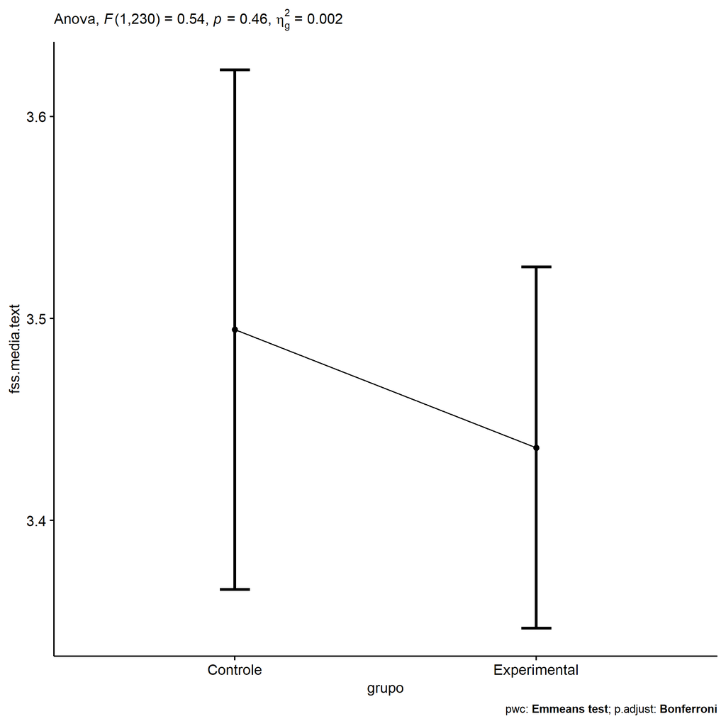

```r
if (!is.null(nrow(plots[["grupo"]]$data)))
  plots[["grupo"]] + ggplot2::scale_color_manual(values = color[["grupo"]])
```

```r
plots <- oneWayAncovaBoxPlots(
  wdat, "fss.media.text", "grupo", aov, pwc, covar = "dfs.media.text",
  theme = "classic", color = color[["grupo"]],
  subtitle = which(aov$Effect == "grupo"))
```

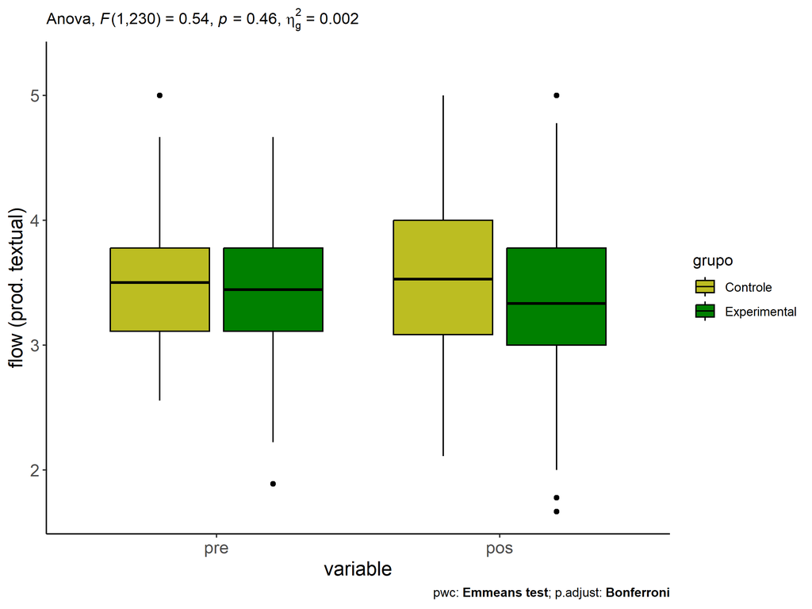

```r
if (length(unique(wdat[["grupo"]])) > 1)
  plots[["grupo"]] + ggplot2::ylab("flow (prod. textual)") + ggplot2::scale_x_discrete(labels=c('pre', 'pos'))
```

```r
if (length(unique(wdat.long[["grupo"]])) > 1)
  plots <- oneWayAncovaBoxPlots(
    wdat.long, "flow.text", "grupo", aov, pwc.long, pre.post = "time",
    theme = "classic", color = color$prepost)
```

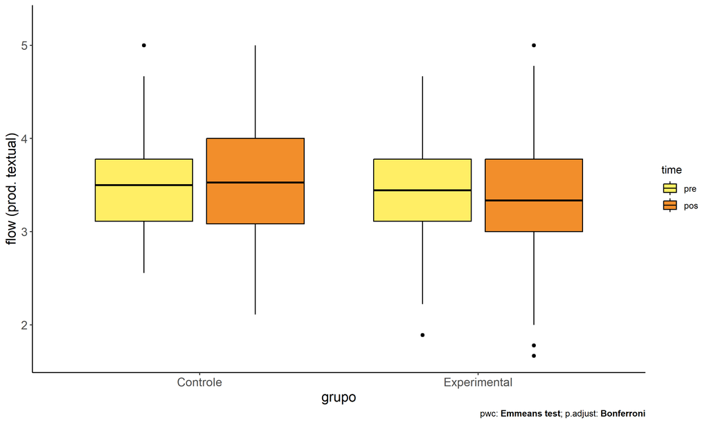

```r
if (length(unique(wdat.long[["grupo"]])) > 1)
  plots[["grupo"]] + ggplot2::ylab("flow (prod. textual)")
```

### Checking linearity assumption

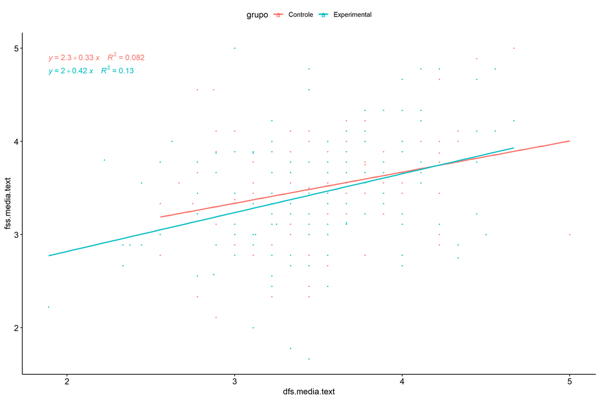

```r
ggscatter(wdat, x = "dfs.media.text", y = "fss.media.text", size = 0.5,
          color = "grupo", add = "reg.line")+
  stat_regline_equation(
    aes(label =  paste(..eq.label.., ..rr.label.., sep = "~~~~"), color = grupo)
  )
```

### Checking normality and homogeneity

```r
res <- augment(lm(fss.media.text ~ dfs.media.text + grupo, data = wdat))
```

```r
shapiro_test(res$.resid)
```

```
## # A tibble: 1 × 3
##   variable   statistic p.value
##   <chr>          <dbl>   <dbl>
## 1 res$.resid     0.998   0.980
```

```r
levene_test(res, .resid ~ grupo)
```

```
## # A tibble: 1 × 4
##     df1   df2 statistic     p
##   <int> <int>     <dbl> <dbl>
## 1     1   231     0.476 0.491
```

# ANCOVA and Pairwise for two factors **grupo:Sexo**

## Without remove non-normal data

```r
pdat = remove_group_data(dat[!is.na(dat[["grupo"]]) & !is.na(dat[["Sexo"]]),], "fss.media.text", c("grupo","Sexo"))

pdat.long <- rbind(pdat[,c("id","grupo","Sexo")], pdat[,c("id","grupo","Sexo")])
pdat.long[["time"]] <- c(rep("pre", nrow(pdat)), rep("pos", nrow(pdat)))
pdat.long[["time"]] <- factor(pdat.long[["time"]], c("pre","pos"))
pdat.long[["flow.text"]] <- c(pdat[["dfs.media.text"]], pdat[["fss.media.text"]])

aov = anova_test(pdat, fss.media.text ~ dfs.media.text + grupo*Sexo)
laov[["grupo:Sexo"]] <- get_anova_table(aov)
```

```r
pwcs <- list()
pwcs[["Sexo"]] <- emmeans_test(
  group_by(pdat, grupo), fss.media.text ~ Sexo,
  covariate = dfs.media.text, p.adjust.method = "bonferroni")
pwcs[["grupo"]] <- emmeans_test(
  group_by(pdat, Sexo), fss.media.text ~ grupo,
  covariate = dfs.media.text, p.adjust.method = "bonferroni")

pwc <- plyr::rbind.fill(pwcs[["grupo"]], pwcs[["Sexo"]])
pwc <- pwc[,c("grupo","Sexo", colnames(pwc)[!colnames(pwc) %in% c("grupo","Sexo")])]
```

```r
pwc.long <- emmeans_test(dplyr::group_by_at(pdat.long, c("grupo","Sexo")),
                         flow.text ~ time,
                         p.adjust.method = "bonferroni")
lpwc[["grupo:Sexo"]] <- plyr::rbind.fill(pwc, pwc.long)
```

```r
ds <- get.descriptives(pdat, "fss.media.text", c("grupo","Sexo"), covar = "dfs.media.text")
ds <- merge(ds[ds$variable != "dfs.media.text",],
            ds[ds$variable == "dfs.media.text", !colnames(ds) %in% c("variable")],
            by = c("grupo","Sexo"), all.x = T, suffixes = c("", ".dfs.media.text"))
ds <- merge(get_emmeans(pwcs[["grupo"]]), ds, by = c("grupo","Sexo"), suffixes = c(".emms", ""))
ds <- ds[,c("grupo","Sexo","n","mean.dfs.media.text","se.dfs.media.text","mean","se","emmean","se.emms")]

colnames(ds) <- c("grupo","Sexo", "N", paste0(c("M","SE")," (pre)"),
                  paste0(c("M","SE"), " (unadj)"), paste0(c("M", "SE"), " (adj)"))

lemms[["grupo:Sexo"]] <- ds
```

## Computing ANCOVA and PairWise After removing non-normal data (OK)

```r
wdat = pdat

res = residuals(lm(fss.media.text ~ dfs.media.text + grupo*Sexo, data = wdat))
non.normal = getNonNormal(res, wdat$id, plimit = 0.05)

wdat = wdat[!wdat$id %in% non.normal,]

wdat.long <- rbind(wdat[,c("id","grupo","Sexo")], wdat[,c("id","grupo","Sexo")])
wdat.long[["time"]] <- c(rep("pre", nrow(wdat)), rep("pos", nrow(wdat)))
wdat.long[["time"]] <- factor(wdat.long[["time"]], c("pre","pos"))
wdat.long[["flow.text"]] <- c(wdat[["dfs.media.text"]], wdat[["fss.media.text"]])


ldat[["grupo:Sexo"]] = wdat

(non.normal)
```

```r
aov = anova_test(wdat, fss.media.text ~ dfs.media.text + grupo*Sexo)
laov[["grupo:Sexo"]] <- merge(get_anova_table(aov), laov[["grupo:Sexo"]], by="Effect", suffixes = c("","'"))

(df = get_anova_table(aov))
```

```
## ANOVA Table (type II tests)
##
##           Effect DFn DFd      F        p p<.05   ges
## 1 dfs.media.text   1 228 28.210 2.58e-07     * 0.110
## 2          grupo   1 228  0.571 4.51e-01       0.002
## 3           Sexo   1 228  0.439 5.08e-01       0.002
## 4     grupo:Sexo   1 228  0.722 3.96e-01       0.003
```

| Effect | DFn | DFd | F | p | p<.05 | ges |
| --- | --- | --- | --- | --- | --- | --- |
| dfs.media.text | 1 | 228 | 28.210 | 0.000 | * | 0.110 |
| grupo | 1 | 228 | 0.571 | 0.451 |  | 0.002 |
| Sexo | 1 | 228 | 0.439 | 0.508 |  | 0.002 |
| grupo:Sexo | 1 | 228 | 0.722 | 0.396 |  | 0.003 |

```r
pwcs <- list()
pwcs[["Sexo"]] <- emmeans_test(
  group_by(wdat, grupo), fss.media.text ~ Sexo,
  covariate = dfs.media.text, p.adjust.method = "bonferroni")
pwcs[["grupo"]] <- emmeans_test(
  group_by(wdat, Sexo), fss.media.text ~ grupo,
  covariate = dfs.media.text, p.adjust.method = "bonferroni")

pwc <- plyr::rbind.fill(pwcs[["grupo"]], pwcs[["Sexo"]])
pwc <- pwc[,c("grupo","Sexo", colnames(pwc)[!colnames(pwc) %in% c("grupo","Sexo")])]
```

| grupo | Sexo | term | .y. | group1 | group2 | df | statistic | p | p.adj | p.adj.signif |
| --- | --- | --- | --- | --- | --- | --- | --- | --- | --- | --- |
|  | F | dfs.media.text*grupo | fss.media.text | Controle | Experimental | 228 | 1.130 | 0.260 | 0.260 | ns |
|  | M | dfs.media.text*grupo | fss.media.text | Controle | Experimental | 228 | -0.122 | 0.903 | 0.903 | ns |
| Controle |  | dfs.media.text*Sexo | fss.media.text | F | M | 228 | 1.076 | 0.283 | 0.283 | ns |
| Experimental |  | dfs.media.text*Sexo | fss.media.text | F | M | 228 | 0.057 | 0.955 | 0.955 | ns |

```r
pwc.long <- emmeans_test(dplyr::group_by_at(wdat.long, c("grupo","Sexo")),
                         flow.text ~ time,
                         p.adjust.method = "bonferroni")
lpwc[["grupo:Sexo"]] <- merge(plyr::rbind.fill(pwc, pwc.long), lpwc[["grupo:Sexo"]], by=c("grupo","Sexo","term",".y.","group1","group2"), suffixes = c("","'"))
```

| grupo | Sexo | term | .y. | group1 | group2 | df | statistic | p | p.adj | p.adj.signif |
| --- | --- | --- | --- | --- | --- | --- | --- | --- | --- | --- |
| Controle | F | time | flow.text | pre | pos | 458 | -0.199 | 0.842 | 0.842 | ns |
| Controle | M | time | flow.text | pre | pos | 458 | 0.408 | 0.684 | 0.684 | ns |
| Experimental | F | time | flow.text | pre | pos | 458 | 0.505 | 0.614 | 0.614 | ns |
| Experimental | M | time | flow.text | pre | pos | 458 | 0.188 | 0.851 | 0.851 | ns |

```r
ds <- get.descriptives(wdat, "fss.media.text", c("grupo","Sexo"), covar = "dfs.media.text")
ds <- merge(ds[ds$variable != "dfs.media.text",],
            ds[ds$variable == "dfs.media.text", !colnames(ds) %in% c("variable")],
            by = c("grupo","Sexo"), all.x = T, suffixes = c("", ".dfs.media.text"))
ds <- merge(get_emmeans(pwcs[["grupo"]]), ds, by = c("grupo","Sexo"), suffixes = c(".emms", ""))
ds <- ds[,c("grupo","Sexo","n","mean.dfs.media.text","se.dfs.media.text","mean","se","emmean","se.emms")]

colnames(ds) <- c("grupo","Sexo", "N", paste0(c("M","SE")," (pre)"),
                  paste0(c("M","SE"), " (unadj)"), paste0(c("M", "SE"), " (adj)"))

lemms[["grupo:Sexo"]] <- merge(ds, lemms[["grupo:Sexo"]], by=c("grupo","Sexo"), suffixes = c("","'"))
```

| grupo | Sexo | N | M (pre) | SE (pre) | M (unadj) | SE (unadj) | M (adj) | SE (adj) |
| --- | --- | --- | --- | --- | --- | --- | --- | --- |
| Controle | F | 41 | 3.569 | 0.077 | 3.594 | 0.107 | 3.560 | 0.089 |
| Controle | M | 35 | 3.469 | 0.094 | 3.414 | 0.084 | 3.419 | 0.096 |
| Experimental | F | 90 | 3.481 | 0.054 | 3.438 | 0.061 | 3.438 | 0.060 |
| Experimental | M | 67 | 3.433 | 0.064 | 3.415 | 0.078 | 3.433 | 0.070 |

### Plots for ancova

```r
plots <- twoWayAncovaPlots(
  wdat, "fss.media.text", c("grupo","Sexo"), aov, pwcs, addParam = c("mean_se"),
  font.label.size=10, step.increase=0.05, p.label="p.adj",
  subtitle = which(aov$Effect == "grupo:Sexo"))
```

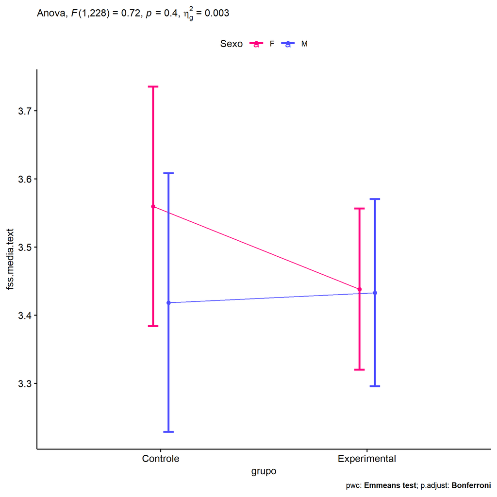

```r
if (!is.null(plots[["grupo"]]))
  plots[["grupo"]] + ggplot2::scale_color_manual(values = color[["Sexo"]])
```

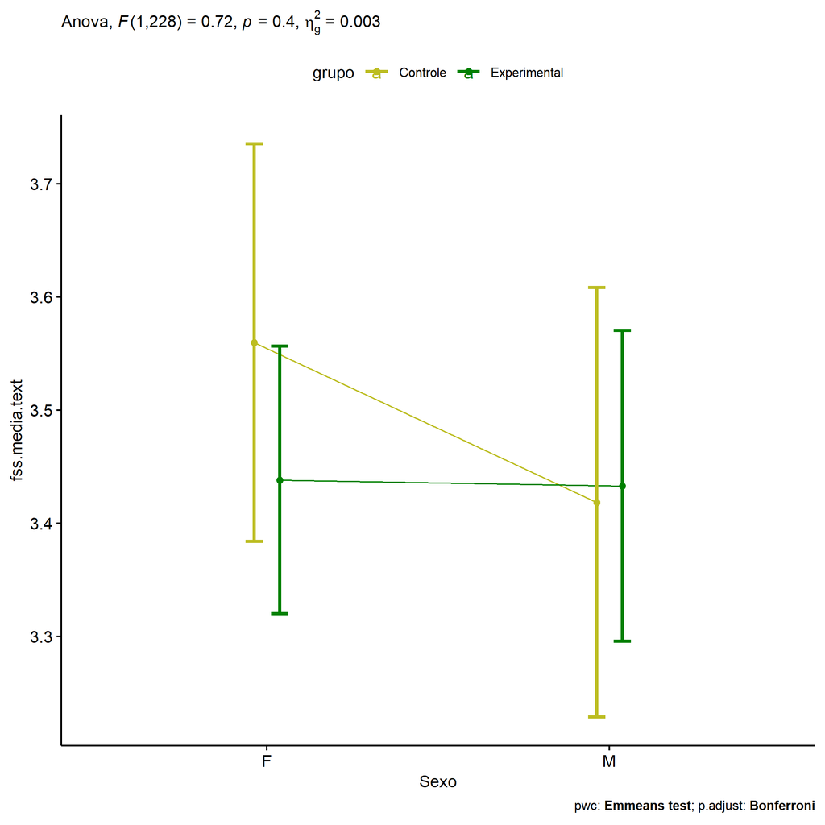

```r
if (!is.null(plots[["Sexo"]]))
  plots[["Sexo"]] + ggplot2::scale_color_manual(values = color[["grupo"]])
```

```r
plots <- twoWayAncovaBoxPlots(
  wdat, "fss.media.text", c("grupo","Sexo"), aov, pwcs, covar = "dfs.media.text",
  theme = "classic", color = color[["grupo:Sexo"]],
  subtitle = which(aov$Effect == "grupo:Sexo"))
```

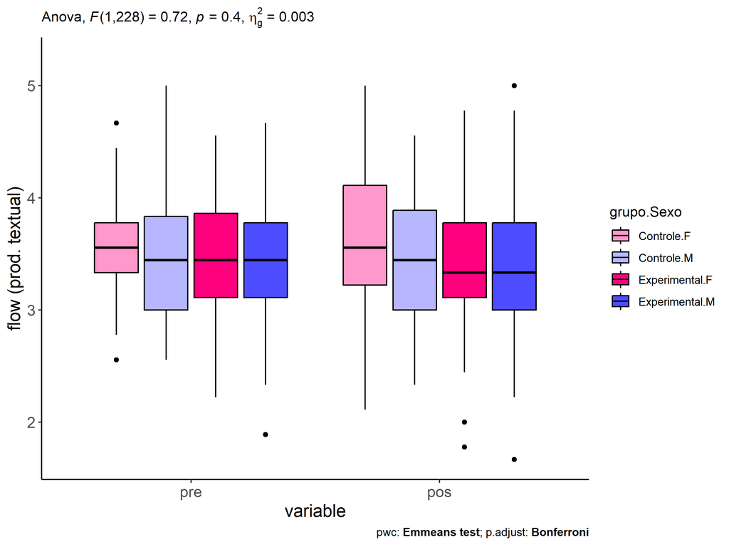

```r
plots[["grupo:Sexo"]] + ggplot2::ylab("flow (prod. textual)") + ggplot2::scale_x_discrete(labels=c('pre', 'pos'))
```

```r
plots <- twoWayAncovaBoxPlots(
  wdat.long, "flow.text", c("grupo","Sexo"), aov, pwc.long, pre.post = "time",
  theme = "classic", color = color$prepost)
```

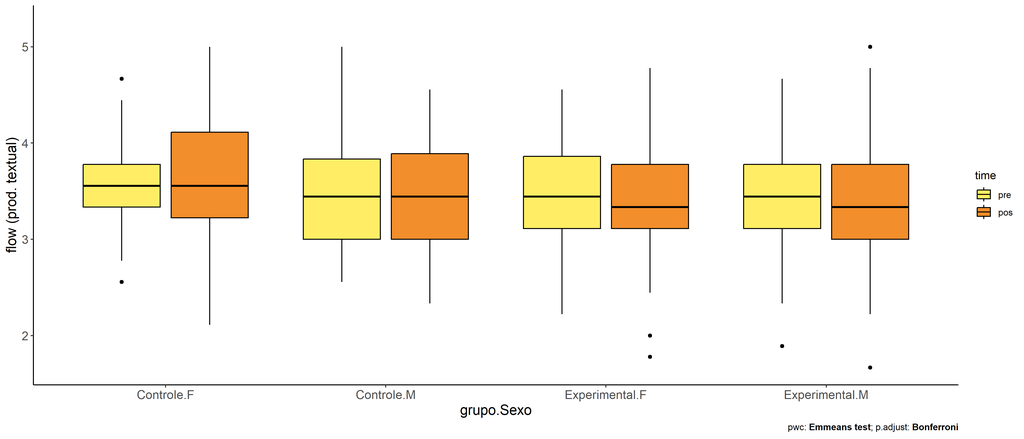

```r
plots[["grupo:Sexo"]] + ggplot2::ylab("flow (prod. textual)")
```

### Checking linearity assumption

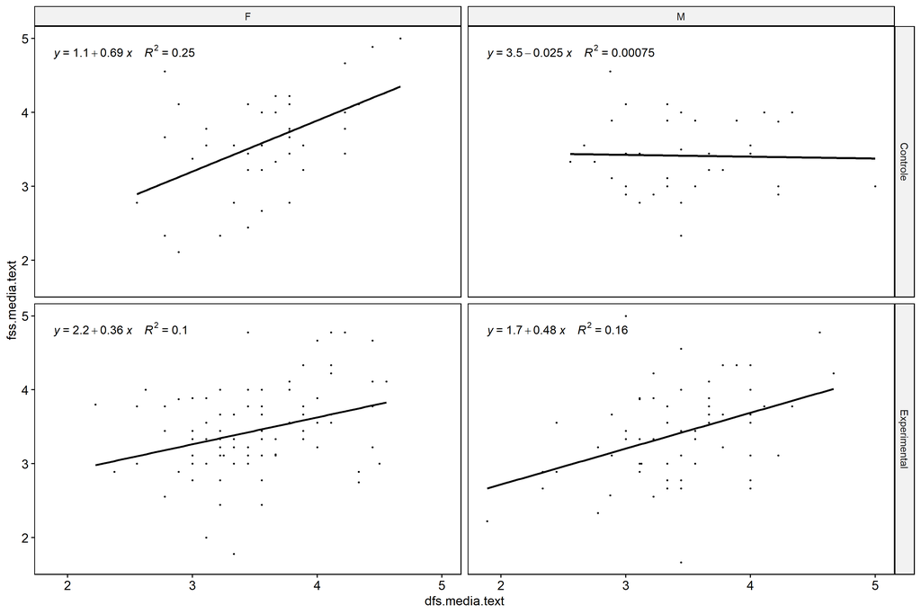

```r
ggscatter(wdat, x = "dfs.media.text", y = "fss.media.text", size = 0.5,
          facet.by = c("grupo","Sexo"), add = "reg.line")+
  stat_regline_equation(
    aes(label =  paste(..eq.label.., ..rr.label.., sep = "~~~~"))
  )
```

### Checking normality and homogeneity

```r
res <- augment(lm(fss.media.text ~ dfs.media.text + grupo*Sexo, data = wdat))
```

```r
shapiro_test(res$.resid)
```

```
## # A tibble: 1 × 3
##   variable   statistic p.value
##   <chr>          <dbl>   <dbl>
## 1 res$.resid     0.998   0.979
```

```r
levene_test(res, .resid ~ grupo*Sexo)
```

```
## # A tibble: 1 × 4
##     df1   df2 statistic     p
##   <int> <int>     <dbl> <dbl>
## 1     3   229     0.328 0.805
```

# ANCOVA and Pairwise for two factors **grupo:Zona**

## Without remove non-normal data

```r
pdat = remove_group_data(dat[!is.na(dat[["grupo"]]) & !is.na(dat[["Zona"]]),], "fss.media.text", c("grupo","Zona"))

pdat.long <- rbind(pdat[,c("id","grupo","Zona")], pdat[,c("id","grupo","Zona")])
pdat.long[["time"]] <- c(rep("pre", nrow(pdat)), rep("pos", nrow(pdat)))
pdat.long[["time"]] <- factor(pdat.long[["time"]], c("pre","pos"))
pdat.long[["flow.text"]] <- c(pdat[["dfs.media.text"]], pdat[["fss.media.text"]])

aov = anova_test(pdat, fss.media.text ~ dfs.media.text + grupo*Zona)
laov[["grupo:Zona"]] <- get_anova_table(aov)
```

```r
pwcs <- list()
pwcs[["Zona"]] <- emmeans_test(
  group_by(pdat, grupo), fss.media.text ~ Zona,
  covariate = dfs.media.text, p.adjust.method = "bonferroni")
pwcs[["grupo"]] <- emmeans_test(
  group_by(pdat, Zona), fss.media.text ~ grupo,
  covariate = dfs.media.text, p.adjust.method = "bonferroni")

pwc <- plyr::rbind.fill(pwcs[["grupo"]], pwcs[["Zona"]])
pwc <- pwc[,c("grupo","Zona", colnames(pwc)[!colnames(pwc) %in% c("grupo","Zona")])]
```

```r
pwc.long <- emmeans_test(dplyr::group_by_at(pdat.long, c("grupo","Zona")),
                         flow.text ~ time,
                         p.adjust.method = "bonferroni")
lpwc[["grupo:Zona"]] <- plyr::rbind.fill(pwc, pwc.long)
```

```r
ds <- get.descriptives(pdat, "fss.media.text", c("grupo","Zona"), covar = "dfs.media.text")
ds <- merge(ds[ds$variable != "dfs.media.text",],
            ds[ds$variable == "dfs.media.text", !colnames(ds) %in% c("variable")],
            by = c("grupo","Zona"), all.x = T, suffixes = c("", ".dfs.media.text"))
ds <- merge(get_emmeans(pwcs[["grupo"]]), ds, by = c("grupo","Zona"), suffixes = c(".emms", ""))
ds <- ds[,c("grupo","Zona","n","mean.dfs.media.text","se.dfs.media.text","mean","se","emmean","se.emms")]

colnames(ds) <- c("grupo","Zona", "N", paste0(c("M","SE")," (pre)"),
                  paste0(c("M","SE"), " (unadj)"), paste0(c("M", "SE"), " (adj)"))

lemms[["grupo:Zona"]] <- ds
```

## Computing ANCOVA and PairWise After removing non-normal data (OK)

```r
wdat = pdat

res = residuals(lm(fss.media.text ~ dfs.media.text + grupo*Zona, data = wdat))
non.normal = getNonNormal(res, wdat$id, plimit = 0.05)

wdat = wdat[!wdat$id %in% non.normal,]

wdat.long <- rbind(wdat[,c("id","grupo","Zona")], wdat[,c("id","grupo","Zona")])
wdat.long[["time"]] <- c(rep("pre", nrow(wdat)), rep("pos", nrow(wdat)))
wdat.long[["time"]] <- factor(wdat.long[["time"]], c("pre","pos"))
wdat.long[["flow.text"]] <- c(wdat[["dfs.media.text"]], wdat[["fss.media.text"]])


ldat[["grupo:Zona"]] = wdat

(non.normal)
```

```r
aov = anova_test(wdat, fss.media.text ~ dfs.media.text + grupo*Zona)
laov[["grupo:Zona"]] <- merge(get_anova_table(aov), laov[["grupo:Zona"]], by="Effect", suffixes = c("","'"))

(df = get_anova_table(aov))
```

```
## ANOVA Table (type II tests)
##
##           Effect DFn DFd      F        p p<.05      ges
## 1 dfs.media.text   1 110 23.758 3.70e-06     * 0.178000
## 2          grupo   1 110  0.677 4.12e-01       0.006000
## 3           Zona   1 110  0.110 7.41e-01       0.000996
## 4     grupo:Zona   1 110  2.679 1.05e-01       0.024000
```

| Effect | DFn | DFd | F | p | p<.05 | ges |
| --- | --- | --- | --- | --- | --- | --- |
| dfs.media.text | 1 | 110 | 23.758 | 0.000 | * | 0.178 |
| grupo | 1 | 110 | 0.677 | 0.412 |  | 0.006 |
| Zona | 1 | 110 | 0.110 | 0.741 |  | 0.001 |
| grupo:Zona | 1 | 110 | 2.679 | 0.105 |  | 0.024 |

```r
pwcs <- list()
pwcs[["Zona"]] <- emmeans_test(
  group_by(wdat, grupo), fss.media.text ~ Zona,
  covariate = dfs.media.text, p.adjust.method = "bonferroni")
pwcs[["grupo"]] <- emmeans_test(
  group_by(wdat, Zona), fss.media.text ~ grupo,
  covariate = dfs.media.text, p.adjust.method = "bonferroni")

pwc <- plyr::rbind.fill(pwcs[["grupo"]], pwcs[["Zona"]])
pwc <- pwc[,c("grupo","Zona", colnames(pwc)[!colnames(pwc) %in% c("grupo","Zona")])]
```

| grupo | Zona | term | .y. | group1 | group2 | df | statistic | p | p.adj | p.adj.signif |
| --- | --- | --- | --- | --- | --- | --- | --- | --- | --- | --- |
|  | Rural | dfs.media.text*grupo | fss.media.text | Controle | Experimental | 110 | -0.265 | 0.792 | 0.792 | ns |
|  | Urbana | dfs.media.text*grupo | fss.media.text | Controle | Experimental | 110 | 1.814 | 0.072 | 0.072 | ns |
| Controle |  | dfs.media.text*Zona | fss.media.text | Rural | Urbana | 110 | -1.128 | 0.262 | 0.262 | ns |
| Experimental |  | dfs.media.text*Zona | fss.media.text | Rural | Urbana | 110 | 1.228 | 0.222 | 0.222 | ns |

```r
pwc.long <- emmeans_test(dplyr::group_by_at(wdat.long, c("grupo","Zona")),
                         flow.text ~ time,
                         p.adjust.method = "bonferroni")
lpwc[["grupo:Zona"]] <- merge(plyr::rbind.fill(pwc, pwc.long), lpwc[["grupo:Zona"]], by=c("grupo","Zona","term",".y.","group1","group2"), suffixes = c("","'"))
```

| grupo | Zona | term | .y. | group1 | group2 | df | statistic | p | p.adj | p.adj.signif |
| --- | --- | --- | --- | --- | --- | --- | --- | --- | --- | --- |
| Controle | Rural | time | flow.text | pre | pos | 222 | -0.046 | 0.963 | 0.963 | ns |
| Controle | Urbana | time | flow.text | pre | pos | 222 | -0.390 | 0.697 | 0.697 | ns |
| Experimental | Rural | time | flow.text | pre | pos | 222 | 0.135 | 0.893 | 0.893 | ns |
| Experimental | Urbana | time | flow.text | pre | pos | 222 | 1.238 | 0.217 | 0.217 | ns |

```r
ds <- get.descriptives(wdat, "fss.media.text", c("grupo","Zona"), covar = "dfs.media.text")
ds <- merge(ds[ds$variable != "dfs.media.text",],
            ds[ds$variable == "dfs.media.text", !colnames(ds) %in% c("variable")],
            by = c("grupo","Zona"), all.x = T, suffixes = c("", ".dfs.media.text"))
ds <- merge(get_emmeans(pwcs[["grupo"]]), ds, by = c("grupo","Zona"), suffixes = c(".emms", ""))
ds <- ds[,c("grupo","Zona","n","mean.dfs.media.text","se.dfs.media.text","mean","se","emmean","se.emms")]

colnames(ds) <- c("grupo","Zona", "N", paste0(c("M","SE")," (pre)"),
                  paste0(c("M","SE"), " (unadj)"), paste0(c("M", "SE"), " (adj)"))

lemms[["grupo:Zona"]] <- merge(ds, lemms[["grupo:Zona"]], by=c("grupo","Zona"), suffixes = c("","'"))
```

| grupo | Zona | N | M (pre) | SE (pre) | M (unadj) | SE (unadj) | M (adj) | SE (adj) |
| --- | --- | --- | --- | --- | --- | --- | --- | --- |
| Controle | Rural | 29 | 3.424 | 0.090 | 3.431 | 0.109 | 3.475 | 0.098 |
| Controle | Urbana | 13 | 3.650 | 0.126 | 3.734 | 0.154 | 3.675 | 0.146 |
| Experimental | Rural | 47 | 3.526 | 0.077 | 3.511 | 0.080 | 3.508 | 0.077 |
| Experimental | Urbana | 26 | 3.557 | 0.117 | 3.367 | 0.123 | 3.351 | 0.103 |

### Plots for ancova

```r
plots <- twoWayAncovaPlots(
  wdat, "fss.media.text", c("grupo","Zona"), aov, pwcs, addParam = c("mean_se"),
  font.label.size=10, step.increase=0.05, p.label="p.adj",
  subtitle = which(aov$Effect == "grupo:Zona"))
```

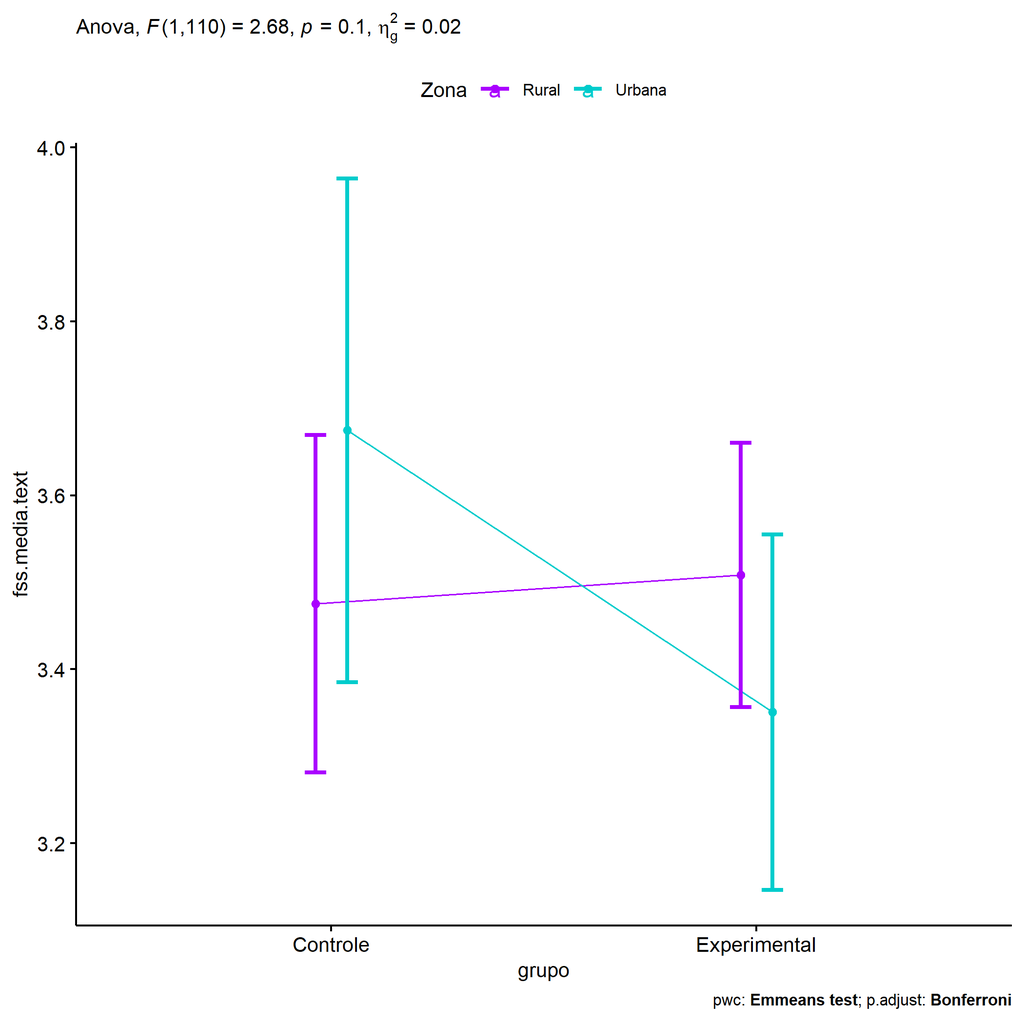

```r
if (!is.null(plots[["grupo"]]))
  plots[["grupo"]] + ggplot2::scale_color_manual(values = color[["Zona"]])
```

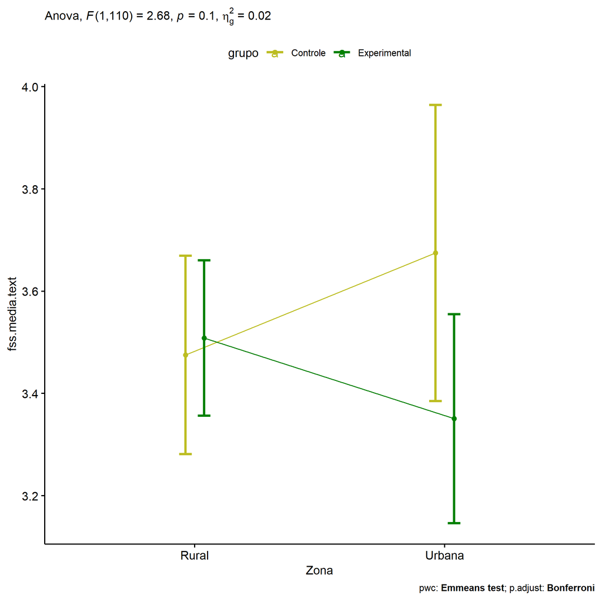

```r
if (!is.null(plots[["Zona"]]))
  plots[["Zona"]] + ggplot2::scale_color_manual(values = color[["grupo"]])
```

```r
plots <- twoWayAncovaBoxPlots(
  wdat, "fss.media.text", c("grupo","Zona"), aov, pwcs, covar = "dfs.media.text",
  theme = "classic", color = color[["grupo:Zona"]],
  subtitle = which(aov$Effect == "grupo:Zona"))
```

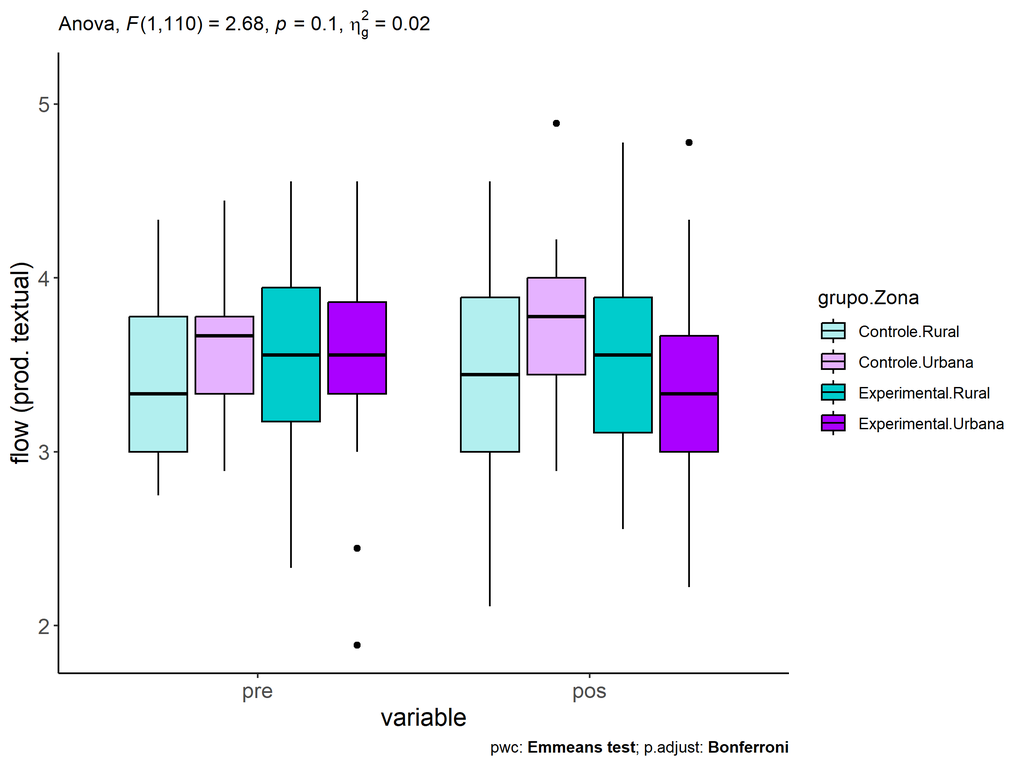

```r
plots[["grupo:Zona"]] + ggplot2::ylab("flow (prod. textual)") + ggplot2::scale_x_discrete(labels=c('pre', 'pos'))
```

```r
plots <- twoWayAncovaBoxPlots(
  wdat.long, "flow.text", c("grupo","Zona"), aov, pwc.long, pre.post = "time",
  theme = "classic", color = color$prepost)
```

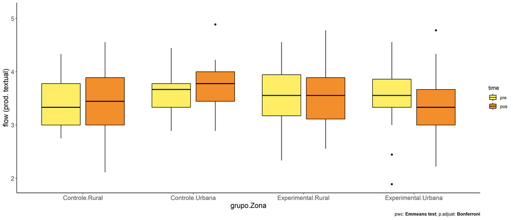

```r
plots[["grupo:Zona"]] + ggplot2::ylab("flow (prod. textual)")
```

### Checking linearity assumption

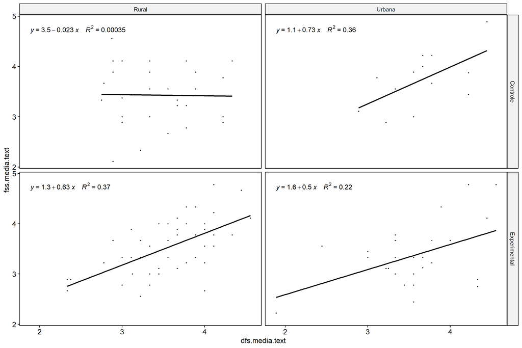

```r
ggscatter(wdat, x = "dfs.media.text", y = "fss.media.text", size = 0.5,
          facet.by = c("grupo","Zona"), add = "reg.line")+
  stat_regline_equation(
    aes(label =  paste(..eq.label.., ..rr.label.., sep = "~~~~"))
  )
```

### Checking normality and homogeneity

```r
res <- augment(lm(fss.media.text ~ dfs.media.text + grupo*Zona, data = wdat))
```

```r
shapiro_test(res$.resid)
```

```
## # A tibble: 1 × 3
##   variable   statistic p.value
##   <chr>          <dbl>   <dbl>
## 1 res$.resid     0.993   0.821
```

```r
levene_test(res, .resid ~ grupo*Zona)
```

```
## # A tibble: 1 × 4
##     df1   df2 statistic     p
##   <int> <int>     <dbl> <dbl>
## 1     3   111      1.64 0.184
```

# ANCOVA and Pairwise for two factors **grupo:Cor.Raca**

## Without remove non-normal data

```r
pdat = remove_group_data(dat[!is.na(dat[["grupo"]]) & !is.na(dat[["Cor.Raca"]]),], "fss.media.text", c("grupo","Cor.Raca"))

pdat.long <- rbind(pdat[,c("id","grupo","Cor.Raca")], pdat[,c("id","grupo","Cor.Raca")])
pdat.long[["time"]] <- c(rep("pre", nrow(pdat)), rep("pos", nrow(pdat)))
pdat.long[["time"]] <- factor(pdat.long[["time"]], c("pre","pos"))
pdat.long[["flow.text"]] <- c(pdat[["dfs.media.text"]], pdat[["fss.media.text"]])

aov = anova_test(pdat, fss.media.text ~ dfs.media.text + grupo*Cor.Raca)
laov[["grupo:Cor.Raca"]] <- get_anova_table(aov)
```

```r
pwcs <- list()
pwcs[["Cor.Raca"]] <- emmeans_test(
  group_by(pdat, grupo), fss.media.text ~ Cor.Raca,
  covariate = dfs.media.text, p.adjust.method = "bonferroni")
pwcs[["grupo"]] <- emmeans_test(
  group_by(pdat, Cor.Raca), fss.media.text ~ grupo,
  covariate = dfs.media.text, p.adjust.method = "bonferroni")

pwc <- plyr::rbind.fill(pwcs[["grupo"]], pwcs[["Cor.Raca"]])
pwc <- pwc[,c("grupo","Cor.Raca", colnames(pwc)[!colnames(pwc) %in% c("grupo","Cor.Raca")])]
```

```r
pwc.long <- emmeans_test(dplyr::group_by_at(pdat.long, c("grupo","Cor.Raca")),
                         flow.text ~ time,
                         p.adjust.method = "bonferroni")
lpwc[["grupo:Cor.Raca"]] <- plyr::rbind.fill(pwc, pwc.long)
```

```r
ds <- get.descriptives(pdat, "fss.media.text", c("grupo","Cor.Raca"), covar = "dfs.media.text")
ds <- merge(ds[ds$variable != "dfs.media.text",],
            ds[ds$variable == "dfs.media.text", !colnames(ds) %in% c("variable")],
            by = c("grupo","Cor.Raca"), all.x = T, suffixes = c("", ".dfs.media.text"))
ds <- merge(get_emmeans(pwcs[["grupo"]]), ds, by = c("grupo","Cor.Raca"), suffixes = c(".emms", ""))
ds <- ds[,c("grupo","Cor.Raca","n","mean.dfs.media.text","se.dfs.media.text","mean","se","emmean","se.emms")]

colnames(ds) <- c("grupo","Cor.Raca", "N", paste0(c("M","SE")," (pre)"),
                  paste0(c("M","SE"), " (unadj)"), paste0(c("M", "SE"), " (adj)"))

lemms[["grupo:Cor.Raca"]] <- ds
```

## Computing ANCOVA and PairWise After removing non-normal data (OK)

```r
wdat = pdat

res = residuals(lm(fss.media.text ~ dfs.media.text + grupo*Cor.Raca, data = wdat))
non.normal = getNonNormal(res, wdat$id, plimit = 0.05)

wdat = wdat[!wdat$id %in% non.normal,]

wdat.long <- rbind(wdat[,c("id","grupo","Cor.Raca")], wdat[,c("id","grupo","Cor.Raca")])
wdat.long[["time"]] <- c(rep("pre", nrow(wdat)), rep("pos", nrow(wdat)))
wdat.long[["time"]] <- factor(wdat.long[["time"]], c("pre","pos"))
wdat.long[["flow.text"]] <- c(wdat[["dfs.media.text"]], wdat[["fss.media.text"]])


ldat[["grupo:Cor.Raca"]] = wdat

(non.normal)
```

```r
aov = anova_test(wdat, fss.media.text ~ dfs.media.text + grupo*Cor.Raca)
laov[["grupo:Cor.Raca"]] <- merge(get_anova_table(aov), laov[["grupo:Cor.Raca"]], by="Effect", suffixes = c("","'"))

(df = get_anova_table(aov))
```

```
## ANOVA Table (type II tests)
##
##           Effect DFn DFd     F     p p<.05   ges
## 1 dfs.media.text   1  85 5.514 0.021     * 0.061
## 2          grupo   1  85 0.309 0.580       0.004
## 3       Cor.Raca   1  85 0.552 0.459       0.006
## 4 grupo:Cor.Raca   0  85    NA    NA  <NA>    NA
```

| Effect | DFn | DFd | F | p | p<.05 | ges |
| --- | --- | --- | --- | --- | --- | --- |
| dfs.media.text | 1 | 85 | 5.514 | 0.021 | * | 0.061 |
| grupo | 1 | 85 | 0.309 | 0.580 |  | 0.004 |
| Cor.Raca | 1 | 85 | 0.552 | 0.459 |  | 0.006 |
| grupo:Cor.Raca | 0 | 85 |  |  |  |  |

```r
pwcs <- list()
pwcs[["Cor.Raca"]] <- emmeans_test(
  group_by(wdat, grupo), fss.media.text ~ Cor.Raca,
  covariate = dfs.media.text, p.adjust.method = "bonferroni")
pwcs[["grupo"]] <- emmeans_test(
  group_by(wdat, Cor.Raca), fss.media.text ~ grupo,
  covariate = dfs.media.text, p.adjust.method = "bonferroni")

pwc <- plyr::rbind.fill(pwcs[["grupo"]], pwcs[["Cor.Raca"]])
pwc <- pwc[,c("grupo","Cor.Raca", colnames(pwc)[!colnames(pwc) %in% c("grupo","Cor.Raca")])]
```

| grupo | Cor.Raca | term | .y. | group1 | group2 | df | statistic | p | p.adj | p.adj.signif |
| --- | --- | --- | --- | --- | --- | --- | --- | --- | --- | --- |
|  | Branca | dfs.media.text*grupo | fss.media.text | Controle | Experimental |  |  |  |  |  |
|  | Parda | dfs.media.text*grupo | fss.media.text | Controle | Experimental | 85 | 0.556 | 0.580 | 0.580 | ns |
| Controle |  | dfs.media.text*Cor.Raca | fss.media.text | Branca | Parda |  |  |  |  |  |
| Experimental |  | dfs.media.text*Cor.Raca | fss.media.text | Branca | Parda | 85 | -0.743 | 0.459 | 0.459 | ns |

```r
pwc.long <- emmeans_test(dplyr::group_by_at(wdat.long, c("grupo","Cor.Raca")),
                         flow.text ~ time,
                         p.adjust.method = "bonferroni")
lpwc[["grupo:Cor.Raca"]] <- merge(plyr::rbind.fill(pwc, pwc.long), lpwc[["grupo:Cor.Raca"]], by=c("grupo","Cor.Raca","term",".y.","group1","group2"), suffixes = c("","'"))
```

| grupo | Cor.Raca | term | .y. | group1 | group2 | df | statistic | p | p.adj | p.adj.signif |
| --- | --- | --- | --- | --- | --- | --- | --- | --- | --- | --- |
| Controle | Branca | time | flow.text | pre | pos |  |  |  |  |  |
| Controle | Parda | time | flow.text | pre | pos | 172 | -1.065 | 0.288 | 0.288 | ns |
| Experimental | Branca | time | flow.text | pre | pos | 172 | 0.672 | 0.502 | 0.502 | ns |
| Experimental | Parda | time | flow.text | pre | pos | 172 | -0.016 | 0.988 | 0.988 | ns |

```r
ds <- get.descriptives(wdat, "fss.media.text", c("grupo","Cor.Raca"), covar = "dfs.media.text")
ds <- merge(ds[ds$variable != "dfs.media.text",],
            ds[ds$variable == "dfs.media.text", !colnames(ds) %in% c("variable")],
            by = c("grupo","Cor.Raca"), all.x = T, suffixes = c("", ".dfs.media.text"))
ds <- merge(get_emmeans(pwcs[["grupo"]]), ds, by = c("grupo","Cor.Raca"), suffixes = c(".emms", ""))
ds <- ds[,c("grupo","Cor.Raca","n","mean.dfs.media.text","se.dfs.media.text","mean","se","emmean","se.emms")]

colnames(ds) <- c("grupo","Cor.Raca", "N", paste0(c("M","SE")," (pre)"),
                  paste0(c("M","SE"), " (unadj)"), paste0(c("M", "SE"), " (adj)"))

lemms[["grupo:Cor.Raca"]] <- merge(ds, lemms[["grupo:Cor.Raca"]], by=c("grupo","Cor.Raca"), suffixes = c("","'"))
```

| grupo | Cor.Raca | N | M (pre) | SE (pre) | M (unadj) | SE (unadj) | M (adj) | SE (adj) |
| --- | --- | --- | --- | --- | --- | --- | --- | --- |
| Controle | Parda | 30 | 3.370 | 0.088 | 3.519 | 0.112 | 3.537 | 0.098 |
| Experimental | Branca | 16 | 3.490 | 0.149 | 3.361 | 0.120 | 3.349 | 0.134 |
| Experimental | Parda | 43 | 3.472 | 0.082 | 3.473 | 0.081 | 3.465 | 0.082 |